# List 3 - Artificial Intelligence

```python
import numpy as np
import pandas as pd
import matplotlib.pyplot as plt
from sklearn.cluster import KMeans
from minisom import MiniSom

from sklearn.datasets import make_blobs
from mpl_toolkits.axes_grid1 import make_axes_locatable
from matplotlib.patches import RegularPolygon
from matplotlib import cm, colorbar
from matplotlib.lines import Line2D
```

# Questão 1

Considere o dados apresentados na tabela abaixo. Obtenha os centroides dos clusters utilizando uma rede neural competitiva que corresponde ao algoritmo K-means. No processo de inicialização considere os itens (a) e (b) abaixo.

| Amostra | $X_1$ | $X_2$ | $X_3$ |
| --- | --- | --- | --- |
| 1 | -5.82 | -4.58 | -1.97 |
| 2 | -4.68 | 2.16 | 3.71 |
| 3 | 3.36 | -3.19 | 1.09 |
| 4 | 7.72 | 0.88 | 1.80 |
| 5 | -7.64 | 3.06 | 3.50 |
| 6 | -6.87 | 0.57 | -5.45 |
| 7 | 4.47 | -2.62 | 5.76 |
| 8 | 7.73 | -2.01 | 5.18 |
| 9 | -7.71 | 3.34 | -6.33 |
| 10 | -5.91 | -0.49 | -5.68 |
| 11 | 2.18 | 3.81 | 5.82 |
| 12 | 6.72 | -0.93 | -3.04 |
| 13 | -5.25 | -0.26 | 0.56 |
| 14 | -6.94 | -1.22 | 1.13 |
| 15 | 7.09 | 0.20 | 2.25 |
| 16 | 6.81 | 3.17 | -4.15 |
| 17 | -4.19 | 4.24 | 4.04 |
| 18 | -5.38 | -1.74 | 1.43 |
| 19 | 5.08 | 3.30 | 5.33 |
| 20 | 7.27 | 0.93 | -2.78 |

### Letra a)

Considere que a rede possui três neurônios que correspondem à existência de três clusters nos dados. Inicialize os pesos dos neurônios (centroides) de forma aleatória

```python
# putting the data in a matrix
x1 = [-5.82, -4.68, 3.36, 7.72, -7.64, -6.87, 4.47, 7.73, -7.71, -5.91, 2.18, 6.72, -5.25, -6.94, 7.09, 6.81, -4.19, -5.38, 5.08, 7.27]
x2 = [-4.58, 2.16, -3.19, 0.88, 3.06, 0.57, -2.62, -2.01, 3.34, -0.49, 3.81, -0.93, -0.26, -1.22, 0.20, 3.17, 4.24, -1.74, 3.30, 0.93]
x3 = [-1.97, 3.71, 1.09, 1.80, 3.50, -5.45, 5.76, 5.18, -6.33, -5.68, 5.82, -3.04, 0.56, 1.13, 2.25, -4.15, 4.04, 1.43, 5.33, -2.78]
```

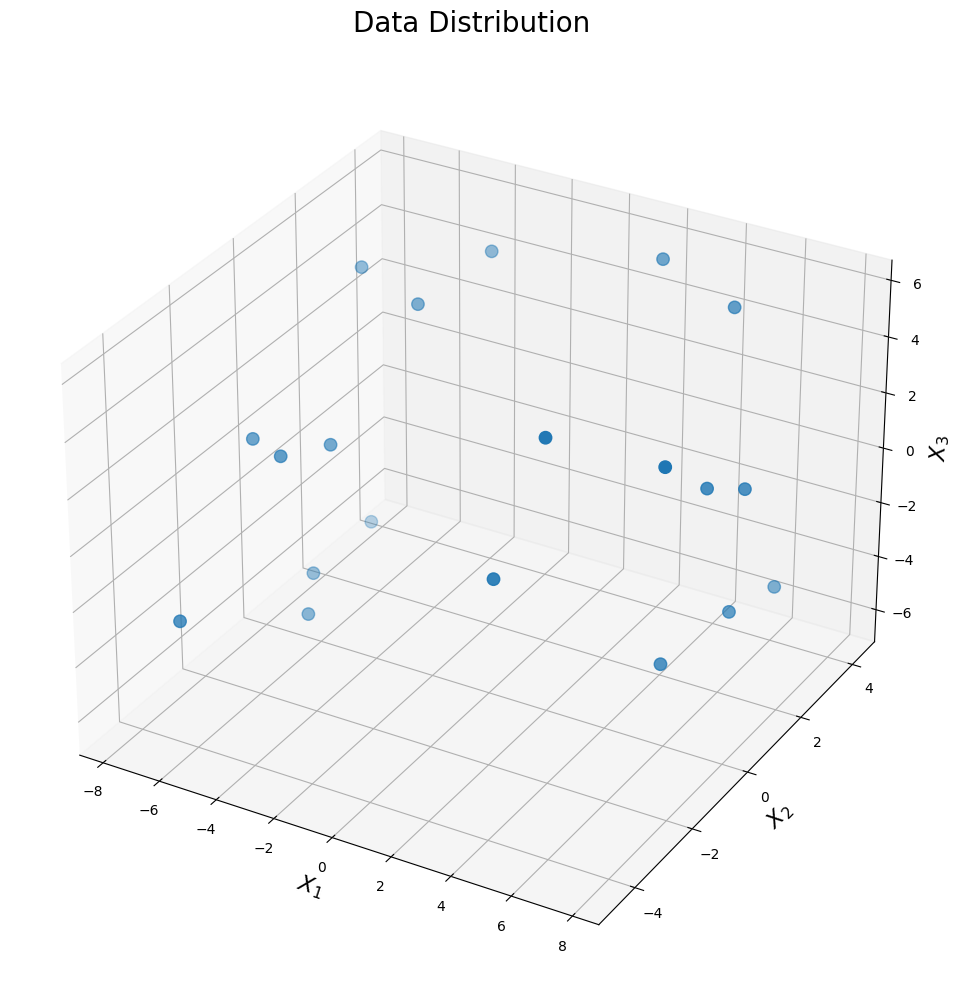

```python
# plot the data
fig = plt.figure(figsize=(12, 12))
ax = fig.add_subplot(projection='3d')

ax.scatter(x1, x2, x3, s=80)
plt.title('Data Distribution', pad=20, size=20)
ax.set_xlabel('$X_1$', fontsize=16)
ax.set_ylabel('$X_2$', fontsize=16)
ax.set_zlabel('$X_3$', fontsize=16)
plt.show()
```

```python
# put the data in a dataframe
df = pd.DataFrame({'x1': x1, 'x2': x2, 'x3': x3})
```

```python
# instantiate the model
kmeans = KMeans(init='random', n_clusters=3, random_state=0, max_iter=1000)

# fit the model
kmeans.fit(df)
```

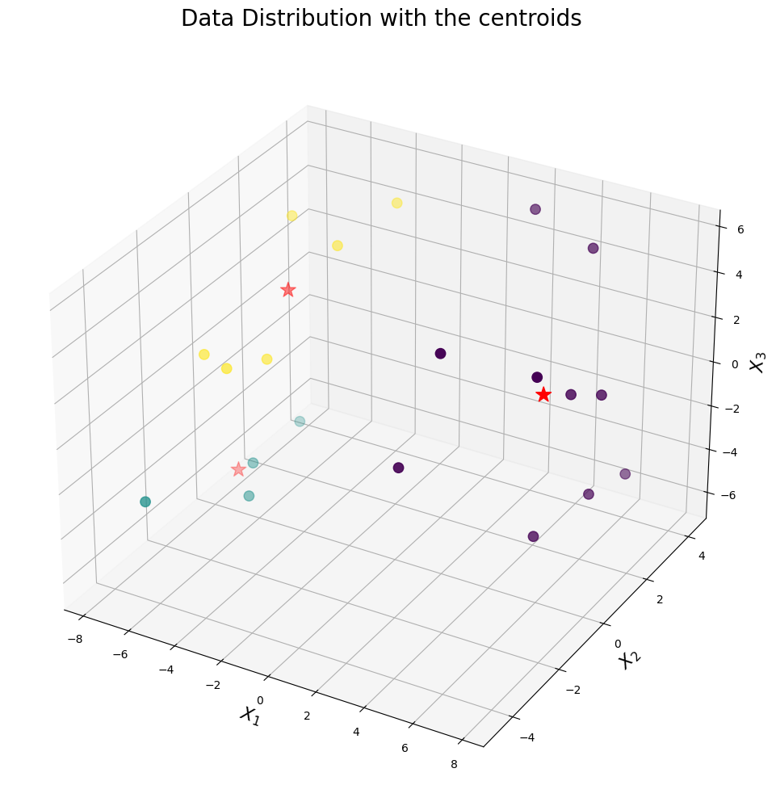

```python
# get the labels
labels = kmeans.labels_

# plot the data hilighting the centroids
fig = plt.figure(figsize=(12, 12))
ax = fig.add_subplot(projection='3d')

ax.scatter(x1, x2, x3, c=labels, s=80)
ax.scatter(kmeans.cluster_centers_[:, 0], kmeans.cluster_centers_[:, 1], kmeans.cluster_centers_[:, 2], c='red', s=200, marker='*')
plt.title('Data Distribution with the centroids', pad=20, size=20)
ax.set_xlabel('$X_1$', fontsize=16)
ax.set_ylabel('$X_2$', fontsize=16)
ax.set_zlabel('$X_3$', fontsize=16)
plt.show()
```

### Letra b)

```python
df
```

|  | x1 | x2 | x3 |
| --- | --- | --- | --- |
| 0 | -5.82 | -4.58 | -1.97 |
| 1 | -4.68 | 2.16 | 3.71 |
| 2 | 3.36 | -3.19 | 1.09 |
| 3 | 7.72 | 0.88 | 1.80 |
| 4 | -7.64 | 3.06 | 3.50 |
| 5 | -6.87 | 0.57 | -5.45 |
| 6 | 4.47 | -2.62 | 5.76 |
| 7 | 7.73 | -2.01 | 5.18 |
| 8 | -7.71 | 3.34 | -6.33 |
| 9 | -5.91 | -0.49 | -5.68 |
| 10 | 2.18 | 3.81 | 5.82 |
| 11 | 6.72 | -0.93 | -3.04 |
| 12 | -5.25 | -0.26 | 0.56 |
| 13 | -6.94 | -1.22 | 1.13 |
| 14 | 7.09 | 0.20 | 2.25 |
| 15 | 6.81 | 3.17 | -4.15 |
| 16 | -4.19 | 4.24 | 4.04 |
| 17 | -5.38 | -1.74 | 1.43 |
| 18 | 5.08 | 3.30 | 5.33 |
| 19 | 7.27 | 0.93 | -2.78 |

```python
# inicialize the model with the centroids in m1, m2 and m3
m1 = [[0],[0],[0]]
m2 = [[1],[1],[1]]
m3 = [[-1],[0],[2]]

init = np.concatenate((m1, m2, m3), axis=1)
init
```

```
array([[ 0,  1, -1],
       [ 0,  1,  0],
       [ 0,  1,  2]])
```

```python
# instantiate the model
kmeans = KMeans(init=init, n_clusters=3, random_state=0, max_iter=1000)

# fit the model
kmeans.fit(df)
```

```
KMeans(init=array([[ 0,  1, -1],
       [ 0,  1,  0],
       [ 0,  1,  2]]),
       max_iter=1000, n_clusters=3, random_state=0)
```

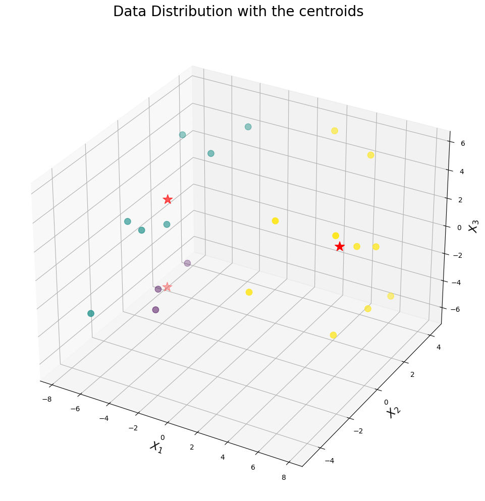

```python
# get the labels
labels = kmeans.labels_

# plot the data hilighting the centroids
fig = plt.figure(figsize=(12, 12))
ax = fig.add_subplot(projection='3d')

ax.scatter(x1, x2, x3, c=labels, s=80)
ax.scatter(kmeans.cluster_centers_[:, 0], kmeans.cluster_centers_[:, 1], kmeans.cluster_centers_[:, 2], c='red', s=200, marker='*')
plt.title('Data Distribution with the centroids', pad=20, size=20)
ax.set_xlabel('$X_1$', fontsize=16)
ax.set_ylabel('$X_2$', fontsize=16)
ax.set_zlabel('$X_3$', fontsize=16)
plt.show()
```

# Questão 2

Considere dados apresentados na tabela abaixo referentes aos índices de desenvolvimento de países (Fonte ONU- 2002, Livro – Análise de dados através de métodos de estatística multivariada – Sueli A. Mingoti) . Utilize uma rede neural de Kohonen ou Mapa Auto Organizável (SOM) para identificar os aglomerados (Clusters) dos países com indicadores mais similares. Como sugestão considere um SOM bidimensional com vizinhança hexagonal com 25x25 neurônios.

[output not shown]

```python
neurons = 25
input_len = 4
```

```python
# writing the data
expected_life = [0.88, 0.90, 0.90, 0.87, 0.93, 0.89, 0.88, 0.81, 0.82, 0.85, 0.77, 0.71, 0.75, 0.70, 0.44, 0.47, 0.23, 0.34, 0.31, 0.24, 0.76]
education = [0.99, 0.99, 0.98, 0.98, 0.93, 0.97, 0.87, 0.92, 0.92, 0.90, 0.85, 0.83, 0.83, 0.62, 0.58, 0.37, 0.33, 0.36, 0.35, 0.37, 0.80]
pib = [0.91, 0.93, 0.94, 0.97, 0.93, 0.92, 0.91, 0.80, 0.75, 0.64, 0.69, 0.72, 0.63, 0.60, 0.37, 0.45, 0.27, 0.51, 0.32, 0.36, 0.80]
politic = [1.10, 1.26, 1.24, 1.18, 1.20, 1.04, 1.41, 0.55, 1.05, 0.07, -1.36, 0.47, -0.87, 0.21, -1.36, -0.68, -1.26, -1.98, -0.55, 0.20, 0.39]
countries = ['Reino Unido', 'Austrália', 'Canadá', 'Estados Unidos', 'Japão', 'França', 'Cingapura', 'Argentina', 'Uruguai', 'Cuba', 'Colômbia',
          'Brasil', 'Paraguai', 'Egito', 'Nigéria', 'Senegal', 'Serra Leoa', 'Angola', 'Etiópia', 'Moçambique', 'China']

expected_life_mean = 0.69
expected_life_std = 0.24

education_mean = 0.75
education_std = 0.249

pib_mean = 0.68
pib_std = 0.229

politic_mean = 0.16
politic_std = 1.056
```

```python
# create a dataframe
df = pd.DataFrame({'countries': countries,
                    'expected_life': expected_life,
                    'education': education,
                    'pib': pib,
                    'politic': politic,
                    })
df.head()
```

|  | countries | expected_life | education | pib | politic |
| --- | --- | --- | --- | --- | --- |
| 0 | Reino Unido | 0.88 | 0.99 | 0.91 | 1.10 |
| 1 | Austrália | 0.90 | 0.99 | 0.93 | 1.26 |
| 2 | Canadá | 0.90 | 0.98 | 0.94 | 1.24 |
| 3 | Estados Unidos | 0.87 | 0.98 | 0.97 | 1.18 |
| 4 | Japão | 0.93 | 0.93 | 0.93 | 1.20 |

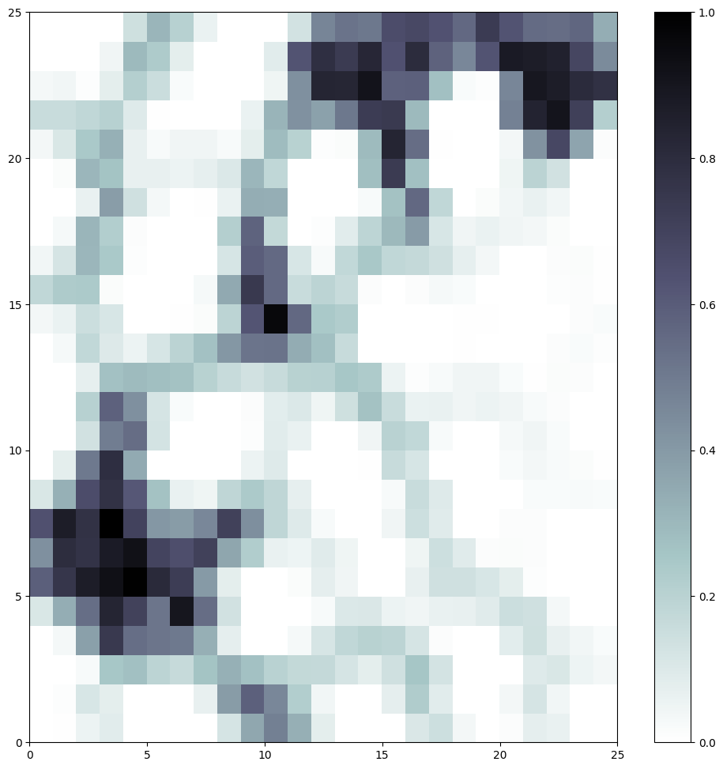

```python
# create a minisom model to cluster the data in 25x25 neurons and hexagonal topology
som = MiniSom(neurons, neurons, input_len, sigma=1.0, learning_rate=0.5, topology='hexagonal', neighborhood_function='gaussian',
                random_seed=10)

# train the model
som.train(df.drop('countries',axis=1).values, 100000)

# plot the data
plt.figure(figsize=(12, 12))
plt.pcolor(som.distance_map().T, cmap='bone_r')
plt.colorbar()
plt.show()
```

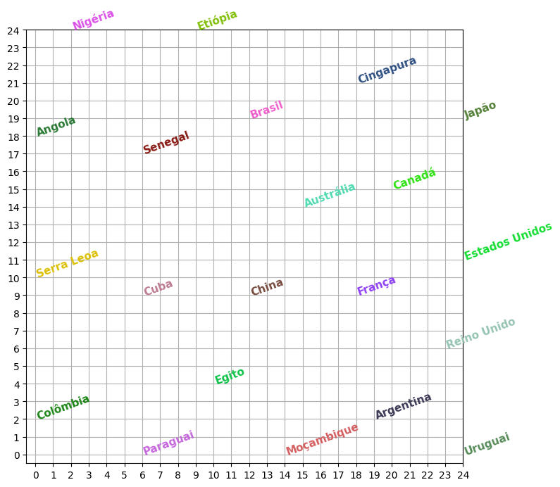

```python
plt.figure(figsize=(8,8))
wmap = {}
im = 0

for x, t in zip(df.drop('countries', axis=1).values, df.countries.values):
  w = som.winner(x)
  wmap[w] = im
  plt.text(
      w[0], w[1], str(t),
      rotation=20,
      c=np.random.rand(3,),
      fontdict={'weight': 'bold', 'size': 11}
  )
  im = im+1

plt.axis([-0.5,9.5,-0.5,9.5])
plt.xticks(range(25))
plt.yticks(range(25))
plt.grid()

plt.show()
```

# Questão 3

Considere quatro distribuições gaussianas, C1, C2, C3, e C4, em um espaço de entrada de dimensionalidade igual a oito, isto é $x = (x_1, x_2, ..., x_8)^t$. Todas as nuvens de dados têm variâncias unitárias, mas centros ou vetores média são diferentes e dados por $m_1 = (0,0,0,0,0,0,0,0)^t$, $m_2 = (4,0,0,0,0,0,0,0)^t$, $m_3 = (0,0,0,4,0,0,0,0)^t$, $m_4 = (0,0,0,0,0,0,0,4)^t$. Utilize uma rede SOM (rede de Kohonen) para reduzir a dimensionalidade dos dados para duas dimensões. O objetivo é visualizar os dados de dimensão 8 em um espaço de dimensão 2. Esboce os dados neste novo espaço.

```python
centers = [
    [ 0, 0, 0, 0, 0, 0, 0, 0 ],
    [ 4, 0, 0, 0, 0, 0, 0, 0 ],
    [ 0, 0, 0, 4, 0, 0, 0, 0 ],
    [ 0, 0, 0, 0, 0, 0, 0, 4 ]
]

data, y = make_blobs(n_samples=10000, centers=centers, n_features=8)
```

```python
np.set_printoptions(precision=3)
data[0:5]
```

```
array([[-0.189, -0.261, -0.912,  3.72 , -0.575, -0.6  , -0.253,  0.847],
       [ 2.509,  1.833,  1.139,  2.065, -0.87 , -0.072, -1.101, -0.948],
       [-0.153,  0.312, -1.958,  0.48 ,  0.008,  0.036,  1.427, -0.378],
       [-1.596, -1.662, -0.555,  4.467, -0.674,  0.394,  0.575, -0.754],
       [ 0.586, -1.36 , -1.618,  0.454,  0.231, -0.833, -1.544, -0.978]])
```

```python
# create a minisom model to cluster the data in 4 clusters
som = MiniSom(15, 15, 8, sigma=2.0, learning_rate=0.7, topology='hexagonal', neighborhood_function='gaussian',
                random_seed=10)

# train the model
som.train(data, 1000000)
```

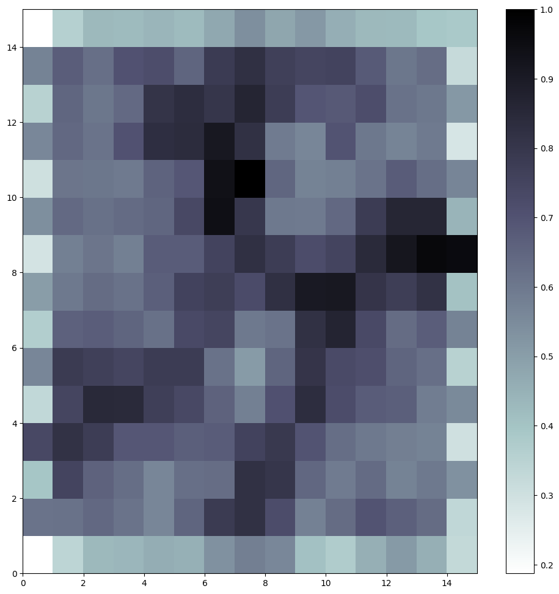

```python
# plot the new data distribution
plt.figure(figsize=(12, 12))
plt.pcolor(som.distance_map().T, cmap='bone_r')
plt.colorbar()
plt.show()
```

```python
xx, yy = som.get_euclidean_coordinates()
umatrix = som.distance_map()
weights = som.get_weights()
```

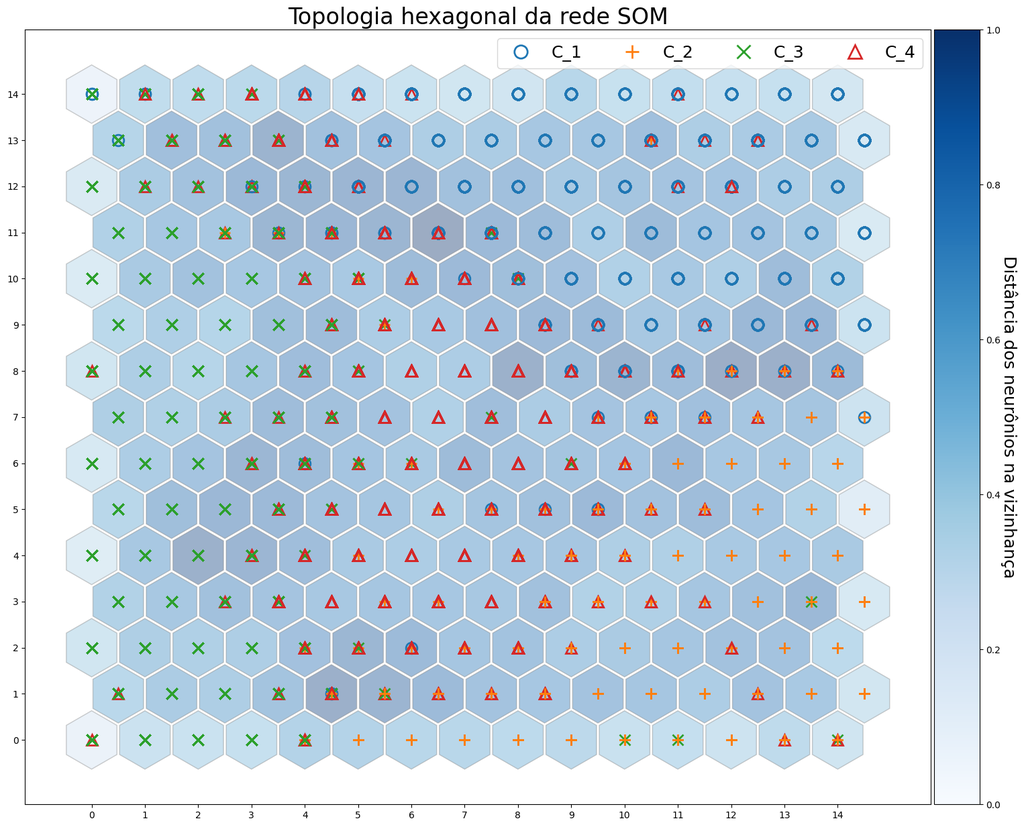

```python
f = plt.figure(figsize=(22, 15))
ax = f.add_subplot(111)

ax.set_aspect('equal')

# iteratively add hexagons
for i in range(weights.shape[0]):
    for j in range(weights.shape[1]):
        wy = yy[(i, j)] * 2 / np.sqrt(3) * 3 / 4
        hex = RegularPolygon(
            (xx[(i, j)], wy),
            numVertices=6,
            radius=.95 / np.sqrt(3),
            facecolor=cm.Blues(umatrix[i, j]),
            alpha=.4,
            edgecolor='gray'
        )
        ax.add_patch(hex)

markers = ['o', '+', 'x', '^']
colors = ['C0', 'C1', 'C2', 'C3']
for cnt, x in enumerate(data):
    # getting the winner
    w = som.winner(x)
    # place a marker on the winning position for the sample xx
    wx, wy = som.convert_map_to_euclidean(w)
    wy = wy * 2 / np.sqrt(3) * 3 / 4
    plt.plot(
        wx, wy,
        markers[y[cnt]-1],
        markerfacecolor='None',
        markeredgecolor=colors[y[cnt]-1],
        markersize=12,
        markeredgewidth=2
    )

xrange = np.arange(weights.shape[0])
yrange = np.arange(weights.shape[1])
plt.xticks(xrange-.5, xrange)
plt.yticks(yrange * 2 / np.sqrt(3) * 3 / 4, yrange)

divider = make_axes_locatable(plt.gca())
ax_cb = divider.new_horizontal(size="5%", pad=0.05)
cb1 = colorbar.ColorbarBase(ax_cb, cmap=cm.Blues, orientation='vertical', alpha=.4)
cb1.ax.get_yaxis().labelpad = 18
cb1.ax.set_ylabel('Distância dos neurônios na vizinhança', rotation=270, fontsize=18)
plt.gcf().add_axes(ax_cb)

legend_elements = [
    Line2D([0], [0], marker='o', color='C0', label='C_1', markerfacecolor='w', markersize=14, linestyle='None', markeredgewidth=2),
    Line2D([0], [0], marker='+', color='C1', label='C_2', markerfacecolor='w', markersize=14, linestyle='None', markeredgewidth=2),
    Line2D([0], [0], marker='x', color='C2', label='C_3',markerfacecolor='w', markersize=14, linestyle='None', markeredgewidth=2),
    Line2D([0], [0], marker='^', color='C3', label='C_4',markerfacecolor='w', markersize=14, linestyle='None', markeredgewidth=2)
]

ax.set_title('Topologia hexagonal da rede SOM', fontsize=24)
ax.legend(handles=legend_elements, loc='upper right', ncol=4, fontsize=18)

#plt.tight_layout()
plt.show()
```

# Questão 4

Pesquise e apresente um trabalho sobre o aprendizagem por reforço profundo (deep reinforcement learning).

Uma das aplicações interessantes e mais promissoras utilizando o deep reinforcement learning é na área de Processamento de Linguagem Natural, especialmente na tradução simultânea de uma lingua para outra. Esta tarefa em especial oferece vários desafios, dadas as diferentes estrututuras das línguas. Por causa disso, muitos tradutores esperam até o fim da sentença para poder realizar a tradução, característica que não é tão interessante quando se quer realizar a tradução em tempo real. Assim, foi realizado um estudo sobre o paper de Boyd-Graber e Morgan (2014)

O autor explica que foi utilizado a aprendizagem por imitação, isto é, dada uma sequência ótima de ações, aprender uma política ótima de ações que mapeia os estados para as ações. Com isso, é desejável que se tenha uma representação das features que permitem o classificar generalizar para exemplos além dos que foram mostrados no treinamento. Para isso, são necessárias três tipos de features:

1. As que representam a entrada (bag of words e um bigrama para modelar efeitos específicos das palavras)
2. As que descrevem as possíveis traduções (representação de bag of words da sentença alvo e os scores das possíveis traduções)
3. As que descrevem a qualidade das predições (As probabilidades das próximas palavras)

O modelo de aprendizagem por imitação utilizado foi o SEARN e foi utilizado o treinamento de uma apenas uma linguagem para a predição do verbo e da próxima palavra. O dataset utilizado foi o German-English Parallel "denews" e possui um total de 48.601 palavras em caixa baixa e separadas pela pontuação. A proporção utilizada para treinamento e teste foi de 70% para a primeira e 30% para a segunda.

Apesar de ser possível melhorar, foi mostrado que os modelos obtiveram bons resultados, como mostra o gráfico abaixo. Além disso, é uma área que existem muitas aplicações para serem criadas e exploradas.

[figure not shown]

**Referência**: http://users.umiacs.umd.edu/~jbg/docs/2014_emnlp_simtrans.pdf

# Questão 5

Pesquise e apresente uma aplicação sobre Sistemas Especialistas.

Os sistemas especialistas são construídos, principalmente, com regras que buscam reproduzir o conhecimento de um perito e são utilizados para solucionar determinados tipos de problemas em domínios específicos. Com isso em vista, buscou-se uma aplicação de sistemas especialistas que pudesse ser relevante para o cotidiano das pessoas. Assim, selecionou-se a utilização de sistemas especialistas na recuperação de informações, o qual é composto basicamente por três elementos, os quais estão demonstrados na figura abaixo:

[figure not shown]

**Interface com o usuário**: Este bloco possui o papel de traduzir todas as informações externas ao sistema especialista para que interajam com ele, seja alimentando-o por informações oriundas de fontes diversas, seja resultantes de informações advindas do usuário mediante perguntas e/ou respostas.

**Base de conhecimento**: Este bloco é composto pela integração de diversas sub-bases de conhecimento constituídas pelas regras que reflitam o conhecimento, as necessidades de informações, periodicidades e o nível de acesso de cada usuário de cada segmento da organização.

**Motor de inferência**: Este bloco é composto pelas heurísticas adotadas para a resolução de problemas e para a execução das tarefas diárias realizadas pelos especialistas. Além disso, este bloco também é utilizado no centro do analisador semântico para auxiliar nas estratégias de raciocínoi adotadas para a compreensão de informações oriundas de diversas fontes de conhecimento, bem como para o entendimento de solicitações realizadas e identificação dos usuários de diversas áreas da organização.

Este tipo de aplicação é muito utilizado pelo Google, por exemplo, quando se é feito uma busca por algum assunto, é possível chegar à resultados semelhantes mesmo utilizando palavras que são diferentes, mas que possuem significados semelhantes. Isso se deve ao analisador semântico mencionado anteriormente e, com isso, é possível perceber que esse analisador requer um bom processamento de linguagem natural para entender o contexto da busca a ser realizada. Além disso, é possível encontrar o uso dos sistemas especialistas na parte de resolução de problemas do Windows, a qual o usuário vai clicando nas possíveis soluções de um determinado problema e o sistema especialista vai sugerindo novas soluções, caso não tenha sido resolvida com a anterior.

**Refência**: https://revista.ibict.br/ciinf/article/view/751/778

# Questão 6

Pesquise e apresente um trabalho sobre o problema do pêndulo invertido fazendo uso da lógica fuzzy.

Para esta questão, foi realizado um estudo sobre o duplo pêndulo invertido utilizando a lógica Fuzzy. Por natureza, este é um sistema instável é mais complicado do que apenas um pêndulo invertido, dado que existem basicamente três variáveis: a distância r, o ângulo $\theta_1$ do primeiro link e o ângulo $\theta_2$ do segundo link.

[figure not shown]

De acordo com o autor do artigo, a maior vantagem dos controladores que utilizam lógica Fuzzy é que eles são simples e que consistem basicamente em três estágios: a camada de entrada, o processamento e a camada de saída. O sinal do sensor é sintonizado na camada de entrada e é combinado com a função de membro para fornecer uma entrada difusa. Na camada de processamento, há uma regra básica que é acionada em resposta a um sinal de entrada e o resultado é enviado para a saída. A camada de saída é onde a saída fuzzy é "defuzzificada" para uma saída nítida. As funções de membro vêm em muitas formas, mas as mais comuns são triangulares, mas também podem ser trapezoidais, sigmoidais ou gaussianas.

Os operadores lógicos que poderiam ser utilizados são AND, OR, e NOT. O número de regras básicas depende do número de entradas e do número de funções dos membros para cada entrada. As regras de relacionamento = $m^n$ mantêm, onde m é o número de funções de associação e n é o número de entradas. Ao projetar um controlador baseado em lógica fuzzy, às vezes há um problema chamado "crescimento explosivo das regras".

Por exemplo, no problema em questão, se usar todas as seis variáveis de estado do pêndulo duplo invertido como entradas com três funções de membro por variável exigiria $3^6$ = 729 regras, o que causaria um problema explosivo, como mencionado anteriormente. Para tratar isso, o autor afirma que foram utilizadas duas entradas: uma para o erro e outra para o erro da derivada. Assim, foram utilizadas as duas variáveis de entrada com sete funções de membro, resultando assim em $7^2$ = 49 regras. O formato das funções de membro de entrada e saída é mostrado na figura abaixo.

[figure not shown]

**Referência**: https://www.mdpi.com/2078-2489/13/8/379/pdf

# Questão 7

**Método de busca em árvore:** A*

O método de busca A* é um dos mais populares na localização de caminhos e travessias em gráficos, possuindo assim várias aplicações na área de jogos, por exemplo.

**Visão geral**

**g** = É o custo do movimento para se mover do ponto de partida para um determinado quadrado na grade, seguindo o caminho gerado para chegar lá. **h** = É o custo estimado de movimento para se mover daquele quadrado dado na grade para o destino final. Isso é muitas vezes referido como heurística, que não é nada além de uma espécie de palpite inteligente. Nós realmente não sabemos a distância real até encontrarmos o caminho, porque todos os tipos de coisas podem estar no caminho (paredes, água, etc.).

**Algoritmo**

1. Inicialize a lista aberta
2. Inicialize a lista fechada coloque o nó inicial em aberto lista (você pode deixar seu f em zero)
3. enquanto a lista aberta não estiver vazia a) encontre o nó com o menor f ligado a lista aberta, chame de "q"  
   b) pop q da lista aberta  
   c) gerar os 8 sucessores de q e definir seus pais para q  
   d) para cada sucessor

   ```
    i) se o sucessor for o objetivo, pare de pesquisar
    ii) caso contrário, calcule g e h para o sucessor successor.
    g = q.g + distância entre sucessor q
    successor.h = distância do objetivo para sucessor //(Isso pode ser feito usando muitos maneiras, discutiremos três heurísticas- Manhattan, Diagonal e Euclidiano Heurística)
    successor.f = successor.g + successor.h
    iii) se um nó com a mesma posição que o sucessor está na lista OPEN que tem um menor do que o sucessor, pule este sucessor
    iV) se um nó com a mesma posição que o sucessor está na lista FECHADA que tem um f menor do que o sucessor, pule este sucessor caso contrário, adicione o nó à lista aberta fim (para loop)
   ```

   e) pressione q na lista fechada fim (enquanto o loop)

## Aplicação

Como foi mencionado anteriormente, esse método de busca é muito utilizado na área de jogos. Assim, neste [repositório](https://github.com/iamjagdeesh/Artificial-Intelligence-Pac-Man/tree/master/Project%201%20Search) é possível encontrar a utilização deste algoritmo no jogo PACMAN. No projeto, eles realizam esta implementação para fazer com que os PACMANs inimigos procurassem o caminho mais eficiente até o PACMAN do jogador.

[figure not shown]

**Referência**: https://github.com/iamjagdeesh/Artificial-Intelligence-Pac-Man/blob/master/Project%201%20Search/search.py

## Implementação

A implementação da árvore A* pode ser encontrada neste repositório e o código encontra-se abaixo:

```
def aStarSearch(problem, heuristic=nullHeuristic):
    """Search the node that has the lowest combined cost and heuristic first."""
    "*** YOUR CODE HERE ***"
    fringe = util.PriorityQueue()    # Fringe (Priority Queue) to store the nodes along with their paths
    visited_nodes = set()    # A set to maintain all the visited nodes
    fringe.push((problem.getStartState(), [], 0), heuristic(problem.getStartState(), problem) + 0)    # Pushing (Node, [Path from start-node till 'Node'], Culmulative backward cost till 'Node') to the fringe. In this case, we are using the sum of culmulative backward cost and the heutristic of the node as a factor based on which priority is decided.
    while True:
        popped_element = fringe.pop()
        node = popped_element[0]
        path_till_node = popped_element[1]
        cost_till_node = popped_element[2]
        if problem.isGoalState(node):    # Exit on encountering goal node
            break
        else:
            if node not in visited_nodes:    # Skipping already visited nodes
                visited_nodes.add(node)     # Adding newly encountered nodes to the set of visited nodes
                successors = problem.getSuccessors(node)
                for successor in successors:
                    child_node = successor[0]
                    child_path = successor[1]
                    child_cost = successor[2]
                    full_path = path_till_node + [child_path]    # Computing path of child node from start node
                    full_cost = cost_till_node + child_cost    # Computing culmulative backward cost of child node from start node
                    fringe.push((child_node, full_path, full_cost), full_cost + heuristic(child_node, problem))    # Pushing (Node, [Path], Culmulative backward cost) to the fringe.

    return path_till_node
```

# Questão 8

Apresente um estudo sobre algoritmos genéticos. Neste estudo apresente a solução (usando algoritmos genéticos) do problema de otimização que consiste na determinação do ponto máximo da função $f(x) = x*sin(10*\pi *x) + 1.0$ Restrita ao intervalo -1,0 <= x < 2,0

```python
def f(x):
    return x*np.sin(10*np.pi*x) + 1.0
```

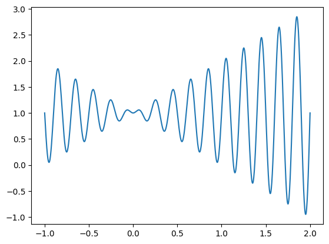

```python
x = np.linspace(-1,2,1000)
y = f(x)

plt.plot(x,y)
plt.show()
```

```python
import numpy

# Inicialização dos parâmetros
genes = 2
chromosomes = 15
mattingPoolSize = 6
offspringSize = chromosomes - mattingPoolSize
lb = -1
ub = 2
populationSize = (chromosomes, genes)
generations = 3

#Inicialização da população
population = numpy.random.uniform(lb, ub, populationSize)

for generation in range(generations):
    print(("Generation:", generation+1))
    fitness = population*numpy.sin(10*np.pi*population) + 1
    print("\npopulation")
    print(population)
    print("\nfitness calcuation")
    print(fitness)
    parents = numpy.empty((mattingPoolSize, population.shape[1]))

    for p in range(mattingPoolSize):
        fittestIndex = numpy.where(fitness == numpy.max(fitness))
        fittestIndex = fittestIndex[0][0]
        parents[p, :] = population[fittestIndex, :]
        fitness[fittestIndex] = -1
    print("\nParents:")
    print(parents)

    offspring = numpy.empty((offspringSize, population.shape[1]))
    for k in range(offspringSize):
         crossoverPoint = numpy.random.randint(0,genes)
         parent1Index = k%parents.shape[0]
         parent2Index = (k+1)%parents.shape[0]
         offspring[k, 0: crossoverPoint] = parents[parent1Index, 0: crossoverPoint]
         offspring[k, crossoverPoint:] = parents[parent2Index, crossoverPoint:]
    print("\nOffspring after crossover:")
    print(offspring)

    for index in range(offspring.shape[0]):
        randomIndex = numpy.random.randint(1,genes)
        randomValue = numpy.random.uniform(lb, ub, 1)
        offspring [index, randomIndex] = offspring [index, randomIndex] + randomValue
    print("\n Offspring after Mutation")
    print(offspring)

    population[0:parents.shape[0], :] = parents
    population[parents.shape[0]:, :] = offspring
    print("\nNew Population for next generation:")
    print(population)

fitness = population*numpy.sin(10*np.pi*population) + 1
fittestIndex = numpy.where(fitness == numpy.max(fitness))
fittestIndex = fittestIndex[0][0]
fittestInd = population[fittestIndex, :]
bestFitness = fitness[fittestIndex]

print("\nBest Individual:")
print(fittestInd)
print("\nBest Individual's Fitness:")
print(bestFitness)
```

```
('Generation:', 1)

population
[[-0.86608212 -0.41901231]
 [ 0.99049577  0.27090856]
 [ 1.85821238  1.86451623]
 [ 0.11817109  1.86046556]
 [ 1.11616173  0.21210774]
 [-0.95164396 -0.13806662]
 [-0.48701725  0.07326829]
 [-0.04522102  0.91090469]
 [ 0.48209165  0.43112164]
 [-0.52510451  1.87098539]
 [-0.62956809  0.16511626]
 [ 0.09961745  1.4816183 ]
 [-0.81715933 -0.57882025]
 [ 0.07191395 -0.71662232]
 [ 0.36222045 -0.90081833]]

fitness calcuation
[[1.75787456 1.2356539 ]
 [0.70862851 1.21453586]
 [2.79670986 2.67396847]
 [0.93614541 2.76081014]
 [0.4573223  1.07874915]
 [0.04962495 0.87152282]
 [1.19317558 1.05454902]
 [1.04471231 0.6940097 ]
 [1.25714456 1.35749574]
 [0.62747796 2.47889471]
 [1.50426336 0.85315511]
 [1.00119718 1.80883415]
 [1.4194835  0.64265997]
 [1.05553437 0.64255385]
 [0.66414751 0.97684385]]

Parents:
[[ 1.85821238  1.86451623]
 [ 0.11817109  1.86046556]
 [-0.52510451  1.87098539]
```

[output cut: 197 more lines]

```
 [1.85821238 1.93871149]
 [1.85821238 1.65425415]
 [1.85821238 1.55109634]
 [1.85821238 1.79140417]
 [1.85821238 5.79932745]
 [0.11817109 2.77767705]
 [1.85821238 1.12496936]
 [1.85821238 3.0682708 ]
 [1.85821238 1.8859558 ]]

Best Individual:
[1.85821238 3.0682708 ]

Best Individual's Fitness:
[2.79670986 3.57654643]
```

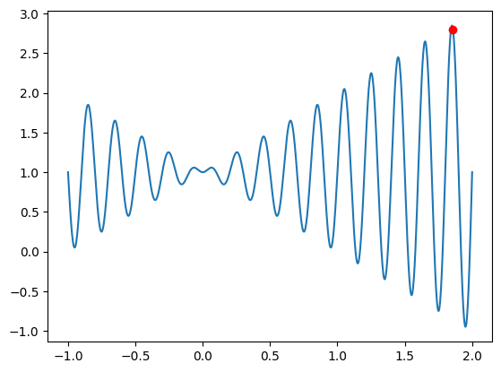

```python
# plot the graph with the best individual
x = np.linspace(-1,2,1000)
y = f(x)
plt.plot(x,y)
plt.plot(fittestInd[0], f(fittestInd)[0], 'ro')
plt.show()
```